# Advanced Visualizations Lecture 05

# Advanced Graphics and Data Visualization in R

# Lecture 05: Dimension Transformation

## 0.1.0 An overview of Advanced Graphics and Data Visualization in R

**“Advanced Graphics and Data Visualization in R”** is brought to you by the Centre for the Analysis of Genome Evolution & Function’s (CAGEF) bioinformatics training initiative. CSB1021 was developed to enhance the skills of students with basic backgrounds in R by focusing on available philosophies, methods, and packages for plotting scientific data. Many of the datasets and examples used in this course will be drawn from real-world datasets and the techniques learned herein aim to be broadly applicable to multiple fields.

This lesson is the fifth in a 6-part series. The aim for the end of this series is for students to recognize how to import, format, and display data based on their intended message and audience. The format and style of these visualizations will help to identify and convey the key message(s) from their experimental data.

The structure of the class is a **code-along style** in R markdown notebooks. At the start of each lecture, skeleton versions of the lecture will be provided for use on the [University of Toronto datatools Hub](https://datatools.utoronto.ca) so students can program along with the instructor.

## 0.2.0 Lecture objectives

This week will focus on exploring the relationships within your data observations comparing between experimental samples and applying a suite of cluster, dimension reduction and projection algorithms.

At the end of this lecture you will have covered visualizations related to:

1. Clustering with heatmaps and dendrograms
2. K-means clustering
3. Principal component analysis
4. Non-linear projections

## 0.3.0 A legend for text format in R markdown

`grey background` - a package, function, code, command or directory. Backticks are also use for in-line code.  
*italics* - an important term or concept or an individual file or folder  
**bold** - heading or a term that is being defined  
blue text - named or unnamed hyperlink

`...` - Within each coding cell this will indicate an area of code that students will need to complete for the code cell to run correctly.

**Blue box:** A key concept that is being introduced

**Yellow box:** Risk or caution

**Green boxes:** Recommended reads and resources to learn R

**Red boxes:** A comprehension question which may or may not involve a coding cell. You usually find these at the end of a section.

## 0.4.0 Lecture and data files used in this course

### 0.4.1 Weekly Lecture and skeleton files

Each week, new lesson files will appear within your RStudio folders. We are pulling from a GitHub repository using this [Repository git-pull link](https://r.datatools.utoronto.ca/hub/user-redirect/git-pull?repo=https%3A%2F%2Fgithub.com%2Fuoft-csb-datasci%2F2026-03-Adv_Graphics_R&urlpath=rstudio%2F&branch=main). Simply click on the link and it will take you to the [University of Toronto datatools Hub](https://datatools.utoronto.ca). You will need to use your UTORid credentials to complete the login process. From there you will find each week’s lecture files in the directory `/2025-03-Adv_Graphics_R/Lecture_XX`. You will find a partially coded `skeleton.Rmd` file as well as all of the data files necessary to run the week’s lecture.

Alternatively, you can download the R-Markdown Notebook (`.Rmd`) and data files from the RStudio server to your personal computer if you would like to run independently of the Toronto tools.

### 0.4.2 Live-coding HTML page

A live lecture version will be available at [camok.github.io](https://camok.github.io/2025-03.Adv_Graphics_R/index.html) that will update as the lecture progresses. Be sure to refresh to take a look if you get lost!

### 0.4.3 Post-lecture Files

At the end of each lecture there will be a completed version of the lecture code released as an HTML file under the Modules section of Quercus.

### 0.4.4 Data used in this lesson

Today’s datasets will focus on two new sets of RNAseq data from differing projects.

### 0.4.4.1 Dataset 1: data/GSE122597_filtered.tsv

This is a filtered RNAseq dataset from the [Immunological Genome Project Consortium](https://www.immgen.org/ImmGenData.html) which houses a [large database of immunological data](https://rstats.immgen.org/DataPage/). Today’s dataset focuses on a series of deeply sequenced immunocyte populations in high replicate numbers. Low-expressing genes from these mouse immune cell populations may be identified as a result of their deep sequencing and more details about this set can be [found here](https://www.ncbi.nlm.nih.gov/geo/query/acc.cgi?acc=GSE122597).

The dataset we use today is normalized read count data that has been filtered down from ~55K genes to ~4K genes.

### 0.4.4.2 Dataset 2: GSE150316_DeseqNormCounts_final.txt

From Desai et al., 2020 on medRxiv doi: https://doi.org/10.1101/2020.07.30.20165241 this dataset has normalized expression counts from RNAseq data. It covers multiple samples and tissues from COVID-positive patients with a focus on lung tissue. The expression data has been unfiltered for SARS-CoV-2 expression data as well.

### 0.4.4.3 Dataset 3: 2020.07.30.20165241-supp_tables.xlsx

From Desai et al., 2020 on medRxiv doi: https://doi.org/10.1101/2020.07.30.20165241 this dataset contains patient information like viral load from tissues that were used for the RNAseq data generated in Dataset 2.

## 0.5.0 Packages used in this lesson

`tidyverse` which has a number of packages including `dplyr`, `tidyr`, `stringr`, `forcats` and `ggplot2`

`viridis` helps to create color-blind palettes for our data visualizations

`RColorBrewer` has some hlepful palettes that we’ll need to colour our data.

`gplots` will be used to help generate heatmap/dendrogram visualizations.

`FactoMineR` and `factoextra` will be used for PCA generation and visualizationn

`Rtsne` and `umap` are packages implementing non-linear projection algorithms

```r
# Some packages can be installed via Bioconductor
# if (!requireNamespace("BiocManager", quietly = TRUE))
#     install.packages("BiocManager")
#
BiocManager::install("ComplexHeatmap")
install.packages("FactoMineR", dependencies = TRUE)
```

```
##
##   There are binary versions available but the source versions are later:
##                  binary source needs_compilation
## FactoInvestigate    1.7  1.9.1             FALSE
## Factoshiny          2.4    2.7             FALSE
## FactoMineR          2.4   2.13              TRUE
```

```
## installing the source packages 'FactoInvestigate', 'Factoshiny', 'FactoMineR'
```

```r
install.packages("factoextra", dependencies = TRUE)
install.packages("Rtsne")
install.packages("umap")
# ------------ Legacy installation code which we hopefully never need again ----------#
# We need to specifically install a package called pbkrtest for the facto packages
# This is due to using an older verion of R
# library(remotes)
# install_version("pbkrtest", "0.5.1")
```

```r
# Packages to help tidy our data
library(tidyverse)
library(readxl)
library(magrittr)

# Packages for the graphical analysis section
library(viridis)
# library(gplots) # heatmap2()
library(ComplexHeatmap) # Heatmap()
library(RColorBrewer)

# Useful for PCA and PCA visualization
library(FactoMineR)
```

[output not shown]

```r
library(factoextra)

# Data projection packages
library(Rtsne)
library(umap)
```

# 1.0.0 Data categorization, dimension reduction, and dimension transformation

Last week we looked at an analysis of RNAseq data through a number of methods starting with broad-level volcano plots and moving towards gene-level expression visualizations with dotplots. In between we stopped to take a look at heatmaps. In this instance we simply used heatmaps to convey expression levels of multiple genes across one or more samples.

Looking more broadly, we now wish to ask questions such as “how *similar* are our samples?”, “can our samples be grouped or categorized in some way?” and “is there an underlying structure or architecture to our data?” We briefly discussed *scatterplot matrices* to help analyse our sample quality among replicate experiments.

We can study these questions using a number of techniques that range from clustering/categorization to projection of high-dimensional data onto a lower set of dimensions (usually 2 or 3).

## 1.1.0 What kind of data do we care about?

We cannot begin our journey until we talk about the nature of the data we are interested in examining. Usually, our data will consist of many samples (observations) with some number of features (variables) captured about each observation. For example, with RNAseq data we could consider the measurements we capture for *each* gene as a separate feature/variable/column.

Conversely you may have hundreds or thousands of samples you’d like to categorize in some way (or show that you can categorize) with just a smaller set of features. For every nut, there is a tool *of sorts* for cracking it!

It’s time to leave many of our `tidyverse` tools behind as we embark on a new journey of data analysis and boldly go wherever next generation sequencing can take us.

[figure not shown]

We’ll begin by importing a “trimmed” RNASeq dataset from the [Immunological Genome Project Consortium](https://www.immgen.org/ImmGenData.html)

```r
rnaSeq.tbl <- read_tsv("data/GSE122597_filtered.tsv")
# Take a quick look at the imported data
head(rnaSeq.tbl)
```

| gene_symbol | B.fo.Sp#1.1 | B.fo.Sp#1.10 | B.fo.Sp#1.11 | B.fo.Sp#1.12 | B.fo.Sp#1.13 | B.fo.Sp#1.14 | B.fo.Sp#1.15 | B.fo.Sp#1.16 | B.fo.Sp#1.2 | B.fo.Sp#1.3 | B.fo.Sp#1.4 | B.fo.Sp#1.5 | B.fo.Sp#1.6 | B.fo.Sp#1.8 | B.fo.Sp#1.9 | MF.PC#1.1 | MF.PC#1.10 | MF.PC#1.11 | MF.PC#1.12 | MF.PC#1.13 | MF.PC#1.14 | MF.PC#1.15 | MF.PC#1.16 | MF.PC#1.2 | MF.PC#1.3 | MF.PC#1.4 | MF.PC#1.5 | MF.PC#1.6 | MF.PC#1.7 | … |
| --- | --- | --- | --- | --- | --- | --- | --- | --- | --- | --- | --- | --- | --- | --- | --- | --- | --- | --- | --- | --- | --- | --- | --- | --- | --- | --- | --- | --- | --- | --- |
| 0610030E20Rik | 214.91626 | 273.46219 | 229.0658 | 221.52943 | 235.78800 | 225.45072 | 255.35506 | 257.66808 | 251.63407 | 224.00270 | 260.60009 | 220.43677 | 226.84651 | 213.77071 | 242.47813 | 138.92139 | 122.63181 | 145.18942 | 109.29562 | 105.82142 | 115.75085 | 117.59898 | 129.51465 | 137.57481 | 141.15437 | 137.59302 | 139.73160 | 117.10370 | 145.59375 | … |
| 1110059E24Rik | 364.85756 | 292.49885 | 291.0258 | 279.96972 | 287.49221 | 268.00062 | 237.03586 | 304.79073 | 375.96436 | 352.65810 | 293.05010 | 313.77186 | 315.81634 | 293.87262 | 334.51692 | 155.94872 | 116.88543 | 155.13352 | 162.12275 | 105.82142 | 109.37580 | 155.44251 | 151.22320 | 130.83037 | 174.03008 | 142.11597 | 168.55894 | 137.25393 | 148.50504 | … |
| 1600012H06Rik | 120.95304 | 129.49745 | 122.2835 | 89.21177 | 120.51302 | 119.07597 | 136.28025 | 105.27141 | 141.11826 | 99.63581 | 105.30361 | 114.19363 | 112.78261 | 94.86943 | 134.60470 | 218.94985 | 189.67297 | 218.77575 | 172.68818 | 217.77355 | 233.68921 | 210.67361 | 207.66545 | 232.83995 | 249.29817 | 207.24641 | 219.00680 | 230.32881 | 244.57740 | … |
| 1600014C10Rik | 91.96439 | 78.33643 | 107.7822 | 75.98000 | 85.76101 | 82.90856 | 91.18683 | 86.22182 | 113.48931 | 65.32770 | 93.71432 | 113.20070 | 105.93878 | 77.34714 | 118.77007 | 88.69076 | 75.70300 | 75.58074 | 51.18578 | 75.87244 | 90.25066 | 81.80105 | 104.33272 | 87.83460 | 73.67263 | 63.41668 | 67.66324 | 92.15580 | 83.48637 | … |
| 1600020E01Rik | 161.93700 | 136.63620 | 202.6998 | 225.94001 | 169.67441 | 161.62587 | 179.25991 | 170.44104 | 186.50868 | 191.83884 | 228.15008 | 160.86117 | 176.65839 | 197.50001 | 150.43933 | 36.75740 | 45.05562 | 43.75962 | 35.33764 | 22.39213 | 87.06313 | 53.16270 | 39.20706 | 57.48464 | 51.17872 | 40.80194 | 36.13333 | 39.38139 | 27.20155 | … |
| 1700017B05Rik | 137.94639 | 84.28539 | 110.4188 | 85.90383 | 102.71321 | 135.03219 | 104.57394 | 79.20355 | 97.70134 | 131.79966 | 98.35003 | 91.35632 | 89.96984 | 86.10828 | 82.15249 | 168.71922 | 173.39154 | 177.01054 | 188.53632 | 156.44945 | 192.25141 | 171.80728 | 187.69358 | 183.09974 | 243.24212 | 161.11235 | 167.65809 | 191.94742 | 235.84355 | … |

```r
# Check the structure of our imported data
str(rnaSeq.tbl)
```

```
## spc_tbl_ [4,258 x 84] (S3: spec_tbl_df/tbl_df/tbl/data.frame)
##  $ gene_symbol    : chr [1:4258] "0610030E20Rik" "1110059E24Rik" "1600012H06Rik" "1600014C10Rik" ...
##  $ B.fo.Sp#1.1    : num [1:4258] 215 365 121 92 162 ...
##  $ B.fo.Sp#1.10   : num [1:4258] 273.5 292.5 129.5 78.3 136.6 ...
##  $ B.fo.Sp#1.11   : num [1:4258] 229 291 122 108 203 ...
##  $ B.fo.Sp#1.12   : num [1:4258] 221.5 280 89.2 76 225.9 ...
##  $ B.fo.Sp#1.13   : num [1:4258] 235.8 287.5 120.5 85.8 169.7 ...
##  $ B.fo.Sp#1.14   : num [1:4258] 225.5 268 119.1 82.9 161.6 ...
##  $ B.fo.Sp#1.15   : num [1:4258] 255.4 237 136.3 91.2 179.3 ...
##  $ B.fo.Sp#1.16   : num [1:4258] 257.7 304.8 105.3 86.2 170.4 ...
##  $ B.fo.Sp#1.2    : num [1:4258] 252 376 141 113 187 ...
##  $ B.fo.Sp#1.3    : num [1:4258] 224 352.7 99.6 65.3 191.8 ...
##  $ B.fo.Sp#1.4    : num [1:4258] 260.6 293.1 105.3 93.7 228.2 ...
##  $ B.fo.Sp#1.5    : num [1:4258] 220 314 114 113 161 ...
##  $ B.fo.Sp#1.6    : num [1:4258] 227 316 113 106 177 ...
##  $ B.fo.Sp#1.8    : num [1:4258] 213.8 293.9 94.9 77.3 197.5 ...
##  $ B.fo.Sp#1.9    : num [1:4258] 242 335 135 119 150 ...
##  $ MF.PC#1.1      : num [1:4258] 138.9 155.9 218.9 88.7 36.8 ...
##  $ MF.PC#1.10     : num [1:4258] 122.6 116.9 189.7 75.7 45.1 ...
##  $ MF.PC#1.11     : num [1:4258] 145.2 155.1 218.8 75.6 43.8 ...
##  $ MF.PC#1.12     : num [1:4258] 109.3 162.1 172.7 51.2 35.3 ...
##  $ MF.PC#1.13     : num [1:4258] 105.8 105.8 217.8 75.9 22.4 ...
##  $ MF.PC#1.14     : num [1:4258] 115.8 109.4 233.7 90.3 87.1 ...
##  $ MF.PC#1.15     : num [1:4258] 117.6 155.4 210.7 81.8 53.2 ...
##  $ MF.PC#1.16     : num [1:4258] 129.5 151.2 207.7 104.3 39.2 ...
##  $ MF.PC#1.2      : num [1:4258] 137.6 130.8 232.8 87.8 57.5 ...
##  $ MF.PC#1.3      : num [1:4258] 141.2 174 249.3 73.7 51.2 ...
##  $ MF.PC#1.4      : num [1:4258] 137.6 142.1 207.2 63.4 40.8 ...
##  $ MF.PC#1.5      : num [1:4258] 139.7 168.6 219 67.7 36.1 ...
##  $ MF.PC#1.6      : num [1:4258] 117.1 137.3 230.3 92.2 39.4 ...
##  $ MF.PC#1.7      : num [1:4258] 145.6 148.5 244.6 83.5 27.2 ...
##  $ MF.PC#1.8      : num [1:4258] 114 121 161 109 31 ...
##  $ MF.PC#1.9      : num [1:4258] 138.4 153.8 222.9 70.9 43.3 ...
##  $ MF.PC#2.1      : num [1:4258] 115 107 185 131 24 ...
##  $ MF.PC#2.2      : num [1:4258] 109.4 101.9 216.2 96 32.2 ...
##  $ MF.PC#2.3      : num [1:4258] 86.9 150.3 258.7 54.2 37.8 ...
##  $ MF.PC#2.4      : num [1:4258] 122.3 149.9 205 72.7 37.8 ...
##  $ MF.PC#2.5      : num [1:4258] 155.6 134.1 240 69.7 49.7 ...
##  $ MF.PC#2.6      : num [1:4258] 120.6 124.6 182.4 82.6 43.8 ...
##  $ MF.PC#2.7      : num [1:4258] 124.1 154.4 221.9 76.9 39.8 ...
```

[output cut: 118 more lines]

```
##   ..   `T.4.Nve.Sp#1.5` = col_double(),
##   ..   `T.4.Nve.Sp#1.6` = col_double(),
##   ..   `T.4.Nve.Sp#1.7` = col_double(),
##   ..   `T.4.Nve.Sp#1.8` = col_double(),
##   ..   `T.4.Nve.Sp#1.9` = col_double(),
##   ..   `Tgd.Sp#1.1` = col_double(),
##   ..   `Tgd.Sp#1.2` = col_double(),
##   ..   `Tgd.Sp#1.3` = col_double(),
##   ..   `Tgd.Sp#1.4` = col_double(),
##   ..   `Tgd.Sp#1.5` = col_double(),
##   ..   `Tgd.Sp#1.6` = col_double(),
##   ..   `Tgd.Sp#1.7` = col_double(),
##   ..   `Tgd.Sp#1.8` = col_double()
##   .. )
##  - attr(*, "problems")=<externalptr>
```

| Sample Coding | Cell Type | Description |
| --- | --- | --- |
| B.fo.Sp | B follicle | Central to T cell-dependent antibody production |
| MF.PC | Peritoneal macrophage | White blood cells of innate immune system that engulf and digest pathogens |
| NK.Sp | Natural Killer cells | White blood cells crucial to the innate immune system |
| T.4.Nve | Naive CD4+ abT cells | Helper T cells part of the adaptive immune system |
| Tgd.Sp | Gamma-delta T cells | Rapid response to pathogens and other cells |

The goal of this processed data is to identify and confirm the expression of genes even at low expression. Looking more broadly, at the dataset, however, we can ask questions such as “how *similar* are our samples?”, “can our samples be grouped or categorized in some way?” and “is there an underlying structure or architecture to our data?”

We can study these questions using a number of techniques that range from clustering/categorization to projection of high-dimensional data onto a lower set of dimensions (usually 2 or 3). We’ll begin, however, with some rudimentary analysis.

### 1.1.1 How many reads do we have in each sample?

Before we continue, let’s quickly visualize our dataset size in terms of total reads. This can quickly give us a sense of how what our colour range might look like for our visualizations.

Is our RNAseq data normalized? Yes, by virtue of the fact that we see decimal values in our data, we can surmise this data has been normalized in some way. In the case of the ImmGen datasets, these are normalized using the `DESeq2` package [as per their documentation](https://www.immgen.org/img/Protocols/ImmGenULI_RNAseq_methods.pdf).

**Is my data normalized?** Before you continue your own RNAseq analysis, you should consider if read count data you are working with is normalized! Last lecture when working with differential expression data, we were examining log-fold change results which would ordinarily be analysed using a normalization of the dispersion.

Today we are examining read count data which is the step *prior* to DE analysis. In the case of RNAseq data generation, each individual sample can produce more or less reads during the sequencing process. This can result in datasets that are different in size by hundreds of thousands to *millions* of reads! Comparing read counts directly this way could be akin to comparing the fuel efficiency of a small hatchback to an 18-wheeler!

Therefore when working with your read count data, you must ensure they are normalized to a metric like **counts per million** (CPM) which accounts for sample size but not gene lengths in your dataset. The `DESeq2` package can also be used to normalize your read counts with the `vst()` function used variance stabilizing transformation to normalize count data across a mean range after accounting for library size.

We’ll make a simple dotplot of our samples to start off

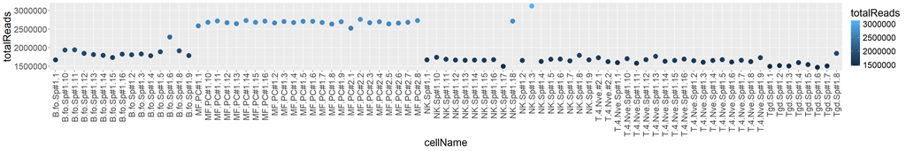

```r
# Take our wide-form dataset
rnaSeq.tbl[, -1] %>%
  # Summarise the total reads using apply()
  apply(., MARGIN = 2, FUN = sum) %>%
  # Cast the named vector to a tibble
  tibble(cellName = names(.), totalReads = .) %>%

  # Plot the data
  ggplot() +

  # 2. Aesthetics
  aes(x = cellName,
      y = totalReads,
      colour = totalReads) +

  # Fix up the text a bit
  theme(text = element_text(size = 20),
        axis.text.x = element_text(angle = 90, vjust = 0.5, hjust = 1)) +

  # 4. Geoms
  geom_point(size = 4)
```

So our total reads per sample appear to span somewhere between 1.5M to a little over 3M reads.

## 1.2.0 Generate a heatmap to visualize large datasets

When we think about our large data, a quick visualization that can work well is the heatmap. This grid-based visualization applies a colour or shade to each value within our cells. With the proper formatting, this can reveal trends or information about our samples. In this visualization, we do not begin by formatting our data in long-format, but rather turn to a package, `ComplexHeatmap` to help us handle things.

From the `ComplexHeatmap` package we can use the function `Heatmap()` to generate a heatmap plot that can do a little more than what we were doing with our `ggplot2` package. A nice aspect of using `Heatmap()` is that we can ask it to reorder our samples along both the rows and columns. At the same time we can present the relationship between columns elements or row elements in the form of dendrograms.

**New Concept: what’s a dendrogram?** A dendrogram is a generalized tree-like structure that shows the relationships between its leaves (or terminal nodes) by connecting them with branches. Leaves on the tree and internal nodes are also joined based on a hierarchical relationship that shows the similarity between nodes. Branch distances should contain informational value representative of the similarity metric used to join leaves and nodes.

### 1.2.1 Subsetting data based on informative or helpful criteria

Before we begin generating our heatmaps, we’ll trim the data down to an even more manageable size for visualization. For our purposes, we’ll filter to the top 200 genes in our dataset based on

1. mean expression levels between 100 - 1000 gene counts. This will make our colour range easier to manage amongst other things.
2. the highest mean counts in the specified range. This should help to give us a set of the more highly-expressed genes within our range.

To accomplish this subsetting, we’ll introduce two new tidyverse verbs: `rowwise` and `c_across`. The `rowwise()` verb, similar to `group_by()` will allow us to group our data by rows so that our new variable(s) will by calculated on a row-by-row basis. This will allow us to calculate a mean gene count *across* each row. Without it, trying to calculate the mean would combine *all* the data in the data frame, creating a single value for the variable we create. Once activated, we can use the `c_across()` helper function to help define which columns we would like to include in our calculation of the mean.

We’ll save this set of genes as our `top200`.

```r
# Create a top 200 set of genes
top200 <-
  rnaSeq.tbl %>%
  # Use rowwise to calculate the mean gene counts across all ROWs
  rowwise() %>%
  # Create a new variable that calculates the mean
  mutate(meanExp = mean(c_across(-1))) %>%
  # Filter for the range we want to visualize
  filter(meanExp > 100,
         meanExp < 1000) %>%
  # Sort the data by highest mean values
  arrange(desc(meanExp)) %>%
  # Retrieve just the gene symbols
  pull(1) %>%
  # Keep the top 200
  .[1:200]

# View our list of 200 genes
top200
```

```
##   [1] "Ifngr1"        "Lnpep"         "Rpl13"         "Clk1"
##   [5] "Actg1"         "Sdha"          "Gpi1"          "Celf2"
##   [9] "Copa"          "Npm1"          "Cltc"          "Zfp207"
##  [13] "Nucb1"         "H2-Ob"         "Idh1"          "Arhgef18"
##  [17] "Ifitm3"        "Alox5ap"       "Msr1"          "Il2rg"
##  [21] "Myo1g"         "Pmp22"         "Rps20"         "Rasal3"
##  [25] "Ikzf1"         "Tgfbr2"        "Pik3cd"        "Cd79a"
##  [29] "Sptbn1"        "Gm2682"        "Sp100"         "Wnk1"
##  [33] "Rpl26"         "Rps13"         "Actr2"         "Ikbkb"
##  [37] "Arhgap15"      "Sash3"         "Ctsz"          "Cd36"
##  [41] "Rpl6"          "Zc3hav1"       "Rap1b"         "Slc25a5"
##  [45] "Stk17b"        "Akr1a1"        "Gramd1a"       "Arl6ip1"
##  [49] "Rasa3"         "Tcf25"         "Hgsnat"        "Cd79b"
##  [53] "Bin2"          "Gm2a"          "Ccr7"          "Mtpn"
##  [57] "Rps16"         "Rplp2"         "Lyn"           "Sh3bgrl"
```

[output cut: 35 more lines]

With our list in hand, we can make a trimmed version of our data frame to work with

```r
rnaSeq_trimmed.tbl <-
  rnaSeq.tbl %>%
  filter(gene_symbol %in% top200)

# Just remember this is technically a tibble!
dim(rnaSeq_trimmed.tbl)
```

```
## [1] 200  84
```

### 1.2.2 Cast our data to a matrix for heatmaps

At this point, we would normally be prepared to visualize our data with `ggplot` but our data is in **wide-format** and we’ll be using a package that prefers to work with **matrix** data. In that case, we need to strip the data down further because matrix data must be all of the same type and we want to work with numeric data! We’ll use `as.matrix()` for our conversion.

```r
# Cast our tibble into a matrix
rnaSeq_trimmed.mx <- as.matrix(rnaSeq_trimmed.tbl[, -1])

# We want to add the rownames back to the matrix, so they can be displayed by `Heatmap()`
rownames(rnaSeq_trimmed.mx) <- pull(rnaSeq_trimmed.tbl, 1)

# check out the structure
str(rnaSeq_trimmed.mx)
```

```
##  num [1:200, 1:83] 570 645 1058 831 1066 ...
##  - attr(*, "dimnames")=List of 2
##   ..$ : chr [1:200] "4932438A13Rik" "AC149090.1" "Acap1" "Actg1" ...
##   ..$ : chr [1:83] "B.fo.Sp#1.1" "B.fo.Sp#1.10" "B.fo.Sp#1.11" "B.fo.Sp#1.12" ...
```

## 1.3.0 Visualize using the `Heatmap()` function

Now that we have a smaller set of data to work with, we can proceed to visualizing our data in a heatmap format. The `Heatmap()` function has quite a number of options and we’ll explore these in a couple of steps but we’ll start with basic version of our data.

Important or helpful parameters to run `Heatmap()`:

- `matrix`: our matrix object. It *must be a matrix*, and not a data frame. It could also be a vector but that becomes a single column.
- `col`: determines the colours used for the image - nothing to do with column names.
- `name`: the name/title of the heatmap (also use as the legend title by default)
- `row_*` : set our row text properties including titles and labels:
  - `row_title`, `row_title_side`, `row_title_gp` (graphic properties)
  - `row_names_side` `row_names_gp`
  - column properties can also be changed using `column_*`
- `cluster_rows` and `cluster_columns`: logical parameters to determine if clustering should occur (default is `TRUE`)
- `show_heatmap_legend`: whether or not to show the heatmap legend
- `heatmap_legend_param`: Set the title of the legend specifically is `list(title = "x")`
- `show_[row/col]_dend`: Whether or not to show dendograms for the row/column

There are actually *a lot* of options but these should help us make a basic heatmap. Let’s plot our data using the matrix version we just made. When creating the heatmap, we’ll save it into a new object `rnaSeq_hmap` and then use the `ComplexHeatmap::draw()` function to visualize the actual object.

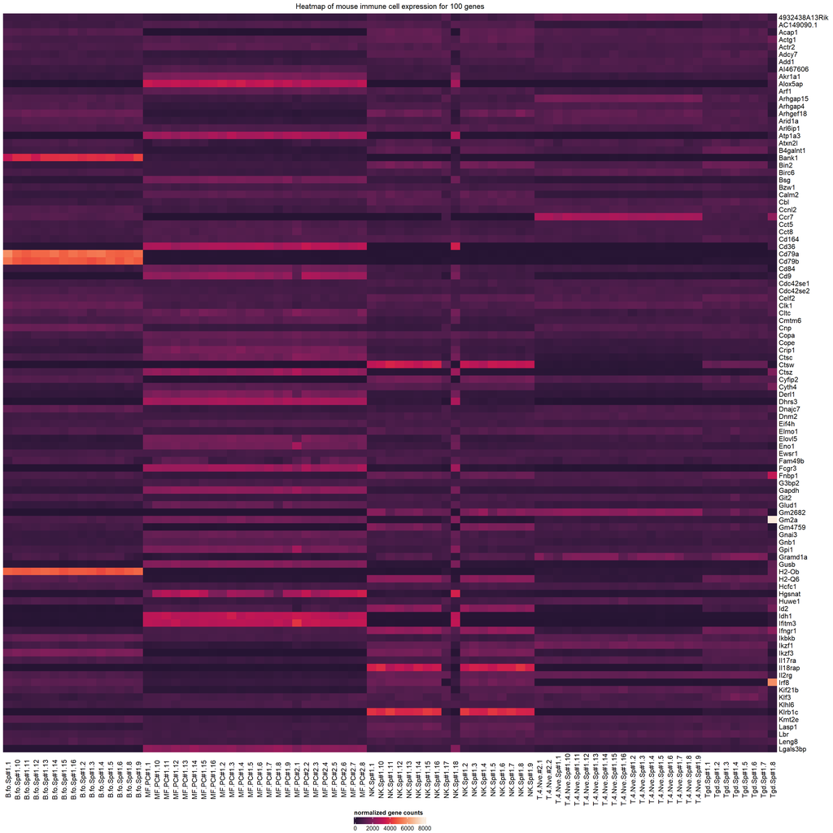

```r
# Create a Heatmap object

rnaSeq_hmap <-
  # Notice we'll only plot out the first 100 genes from our already-trimmed dataset
  Heatmap(matrix = rnaSeq_trimmed.mx[1:100,],

          # Don't cluster on either rows or columns
          cluster_rows = FALSE, cluster_columns = FALSE,

          # Use column_title as the title of our heatmap
          column_title = "Heatmap of mouse immune cell expression for 100 genes",

          # Rotate the legend horizontally and give it a title
          heatmap_legend_param = list(title = "normalized gene counts",
                                      legend_direction = "horizontal"),

          # Rotate column names to horizontal
          column_names_rot = 90,
          column_names_center = TRUE,

          # Set the colour map using the viridis colour scale
          # Go with a slightly brighter start point so our lower expression genes are easier to see
          col = viridis(1000, alpha = 0.5, option = "rocket", begin = 0.1)
          )

# Plot the heatmap
ComplexHeatmap::draw(rnaSeq_hmap,
     # Plot the legend on the bottom
     heatmap_legend_side = "bottom"
    )
```

### 1.3.1 How do we reorder our data via clustering?

In its current form, we have our ordered our data along the columns in an ascending arrangement mostly by sample name and along our y-axis the rows are sorted in order of gene symbol. While this makes sense to us now, it may not help to visually identify the strongest trends or groupings in our data. Clustering attempts to bring order to our data by grouping data according to specific algorithms.

Let’s see what happens when we update the code to cluster our data into dendrograms on the x and y axes.

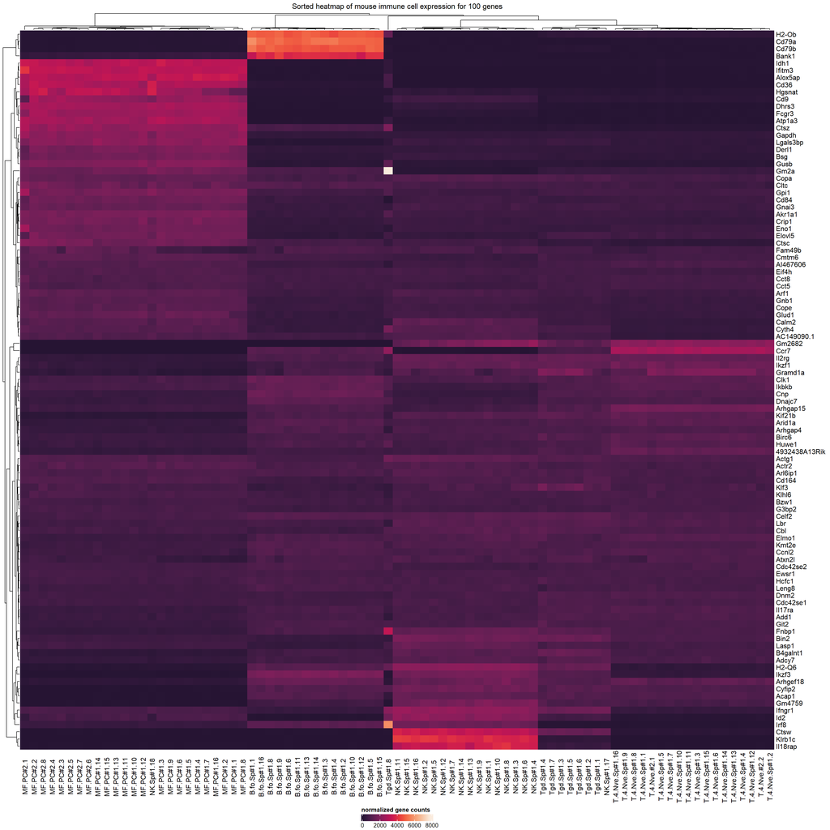

```r
### 1.3.1 Create a Heatmap object

rnaSeq_hmap_sorted <-
  # Notice we'll only plot out the first 100 genes from our already-trimmed dataset
  Heatmap(matrix = rnaSeq_trimmed.mx[1:100,],

          ### 1.3.1 Cluster on both rows AND columns
          cluster_rows = TRUE, cluster_columns = TRUE,

          # Use column_title as the title of our heatmap
          column_title = "Sorted heatmap of mouse immune cell expression for 100 genes",

          # Rotate the legend horizontally and give it a title
          heatmap_legend_param = list(title = "normalized gene counts",
                                      legend_direction = "horizontal"),

          # Rotate column names to horizontal
          column_names_rot = 90,
          column_names_center = TRUE,

          # Set the colour map using the viridis colour scale
          # Go with a slightly brighter start point so our lower expression genes are easier to see
          col = viridis(1000, alpha = 0.5, option = "rocket", begin = 0.1)
          )

# Plot the heatmap
ComplexHeatmap::draw(rnaSeq_hmap_sorted,
     # Plot the legend on the bottom
     heatmap_legend_side = "bottom"
    )
```

What just happened to our heatmap?

The clustered output of our heatmap has grouped together similar looking samples (columns) as well as similar looking rows (gene symbols). Looking at the dimensions of our heatmap, we have 83 samples, and 100 gene symbols.

1. In terms of **each sample** we can identify it by the read count values across 100 gene symbols. In essence, each sample can then be coded as a single point in a 100 dimension space. You can think of this set of 100 values then as the single-point 100-dimension address!
2. For each gene symbol the same process is undertaken using the counts based on the 83 samples in an 83-dimensional plane. Thus each gene also has its own unique n-dimensional address!

If you can imagine these n-dimensional spaces, then overall, single points are usually grouped together as neighbours determined with a “nearest” neighbours metric of some kind. In our case, how far away are any two points, p and q, along the 100 dimensions? A simple metric you can imagine, for example, is the euclidean distance formula:

$$d(p,q) = \sqrt{(p_{1}-q_{2})^2 +
(p_{2}-q_{2})^2 + \ldots + (p_{n}-q_{n})^2}$$
From this calculation, pairs of points (p, q) with the smallest distance can be considered as neighbours.

These neighbours are then further grouped into larger groups we call clusters, using the same metrics until the entire set is presented in these ordered groups. These groupings/relationships can also be presented as dendrograms. On a dendrogram, closest neighbours would be linked together, then the next nearest neighbours are joined to that pair, and repeated etc! In our current case, we aren’t concerned with determining close groups *per se* (aka clusters) but rather with just connecting them by their similarity and then creating a hierarchical order that makes sense visually.

By ordering the data as it is visualized, we now see more specific trends in our data. For instance, the `B.fo` (Follicular B) series of cells has a set of highly expressed genes clustered at the top of our heatmap. Similarly, the NK cells have a small cluster of 3 highly expressed genes at the bottom of our heatmap. In the middle, our MF cells (macrophage) have a large group of moderately expressed cells clustered together.

Overall, our data begins to create a *picture* (pun intended) of the trends in our data - which genes are more or less expressed in each group of cells. We also see (to our relief) that nearly all of the cells of the same type (by label), do appear to cluster together based on the expression of the genes alone - agnostic of the actual sample labels!

[figure not shown]

Now imagine we tried to do this with all 4000+ gene symbols or the original 55K? It would be far too much data to work with by hand or look at by eye!

## 1.4.0 Correlating your data by read count

What if we were to produce a heatmap directly with all 4000+ genes of our data? It would be impossible to read, and including a dendrogram would actually take a while to process given the ~4K rows of data to process across the 83 datasets. That’s another good reason as to why we used a small subset of data as an example to build a heatmap.

From the previous output, we can see that our heatmap is already quite hard to read and that’s coming off of using just 100 genes! We do, however, get some strong trends regarding our datasets - we can see certain sets of replicates are grouped together. This might be clearer if we were to factor in all of the datapoints or just the relevant genes that define the differences between datasets. We’ll discuss the second part of that thought later in this lecture.

Recall that what we’re really interested in, regarding these read count data, is to ask “how similar are the experiments compared to each other?” We can use the idea of correlation to not just ask “How similar is one gene to another gene” but to even ask “How similar is one sample to another sample”. Much like our hierarchical clustering in n-dimensional space, we can use correlation to determine the relationship between samples. This can boil down 4000 datapoints into a single value!

To compare two samples, for instance, we can ask if they share a mathematical relationship. When gene A in sample 1 has a high read count, is it also high in sample 2? We track the difference in value for all genes between both samples and come up with a metric of how well they follow each other. If we were to plot genes counts for samples 1 vs 2 in our example, a positive correlation would result in the points falling along a diagonal line of slope 1. If they were negatively correlated then we would see our points fall along a line of slope -1. A slope of 0 would indicate not real relationship in gene counts between samples 1 and 2.

Recall that last lecture we discussed the **scatterplot matrix** which allowed us to visually compare 6 samples in an all-by-all matter. We cannot feasibly accomplish that visualiation using the 83 samples in our data but a well-made heatmap just might be able to take its place!

Let’s quickly plot some of the trimmed RNAseq data to see what that looks like.

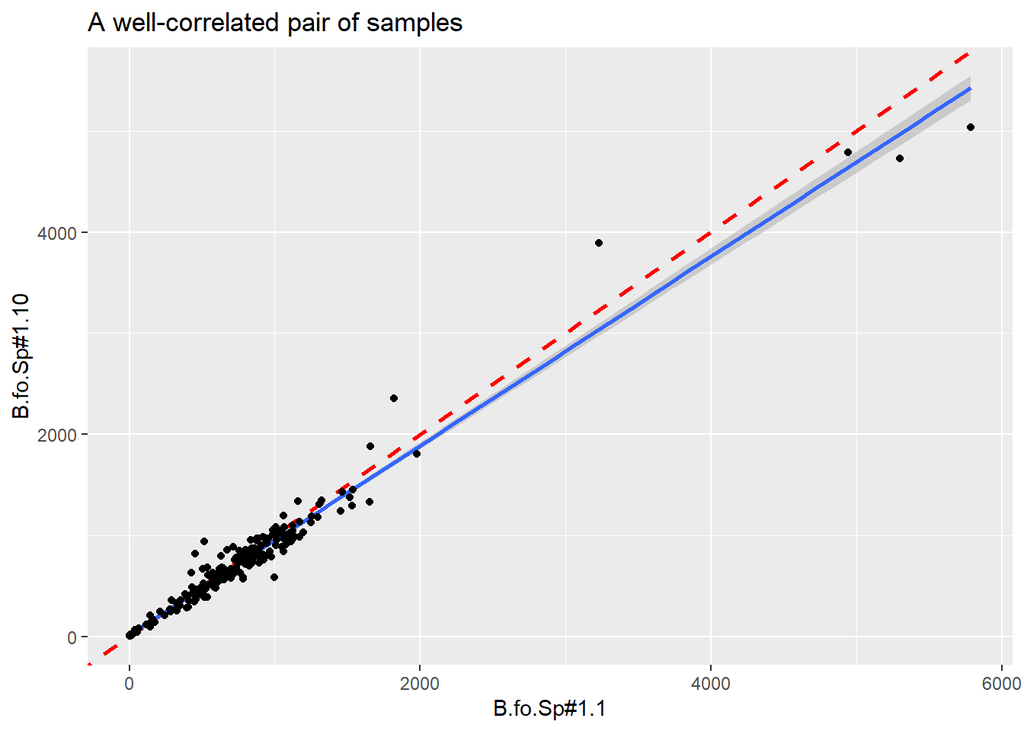

```r
# Well-correlated pairs
rnaSeq_trimmed.tbl %>%
  ggplot() +
  aes(x = `B.fo.Sp#1.1`, y = `B.fo.Sp#1.10`) +
  ggtitle("A well-correlated pair of samples") +
  # Add a positive correlation line
  geom_abline(intercept = 0, slope = 1, colour = "red", linetype = "dashed", linewidth = 1) +
  # Add a regression line
  geom_smooth(method = "lm") +
  geom_point()
```

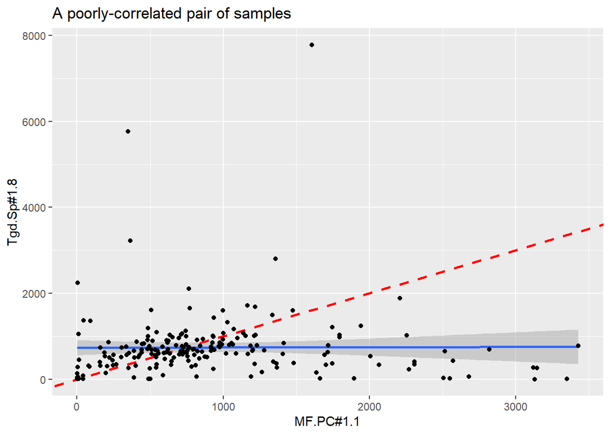

```r
# Poorly correlated samples
rnaSeq_trimmed.tbl %>%
  ggplot() +
  aes(x = `MF.PC#1.1`, y = `Tgd.Sp#1.8`) +
  ggtitle("A poorly-correlated pair of samples") +
  # Add a positive correlation line
  geom_abline(intercept = 0, slope = 1, colour = "red", linetype = "dashed", linewidth = 1) +
  # Add a regression line
  geom_smooth(method = "lm") +
  geom_point()
```

### 1.4.1 Calculate the correlations between samples in a pairwise manner with `cor()`

Looking at our plots, we can extend that idea forward to do a pair-wise comparison between *all* samples and then visually summarize the data as a heatmap! Our heatmap will be a symmetrical matrix because our rows and columns will both be made of samples names and the correlation values between those samples.

Luckily for us, the `cor()` method was built with this kind of comparison in mind. While it can take two sets of data (ie `x` and `y` of the same dimensions) it will do an all-by-all comparison of columns when given a single matrix-like dataset. For us, that means our `rnaseq_trimmed.mx` from earlier would be a good candidate for correlation analysis.

Let’s produce a correlation matrix of our 200-row matrix dataset.

```r
# Create a correlation matrix of the top 200 genes on 83 samples

rnaSeq_trimmed_cor.mx <- cor(rnaSeq_trimmed.mx, method = "pearson")

# take a look at the final matrix
head(rnaSeq_trimmed_cor.mx)
```

```
##              B.fo.Sp#1.1 B.fo.Sp#1.10 B.fo.Sp#1.11 B.fo.Sp#1.12 B.fo.Sp#1.13
## B.fo.Sp#1.1    1.0000000    0.9829377    0.9773514    0.9807187    0.9787699
## B.fo.Sp#1.10   0.9829377    1.0000000    0.9940152    0.9918428    0.9936496
## B.fo.Sp#1.11   0.9773514    0.9940152    1.0000000    0.9928570    0.9949009
## B.fo.Sp#1.12   0.9807187    0.9918428    0.9928570    1.0000000    0.9939372
## B.fo.Sp#1.13   0.9787699    0.9936496    0.9949009    0.9939372    1.0000000
## B.fo.Sp#1.14   0.9796963    0.9950013    0.9947037    0.9939110    0.9950700
##              B.fo.Sp#1.14 B.fo.Sp#1.15 B.fo.Sp#1.16 B.fo.Sp#1.2 B.fo.Sp#1.3
## B.fo.Sp#1.1     0.9796963    0.9795638    0.9824587   0.9811542   0.9793090
## B.fo.Sp#1.10    0.9950013    0.9911222    0.9924295   0.9934849   0.9925819
## B.fo.Sp#1.11    0.9947037    0.9899915    0.9911779   0.9928971   0.9915648
## B.fo.Sp#1.12    0.9939110    0.9895457    0.9886285   0.9914350   0.9909890
## B.fo.Sp#1.13    0.9950700    0.9914472    0.9905341   0.9921349   0.9924557
## B.fo.Sp#1.14    1.0000000    0.9904162    0.9927450   0.9922655   0.9931766
##              B.fo.Sp#1.4 B.fo.Sp#1.5 B.fo.Sp#1.6 B.fo.Sp#1.8 B.fo.Sp#1.9
## B.fo.Sp#1.1    0.9799243   0.9787471   0.9747021   0.9840174   0.9807301
## B.fo.Sp#1.10   0.9924627   0.9941565   0.9910011   0.9921773   0.9880688
## B.fo.Sp#1.11   0.9924687   0.9942267   0.9926971   0.9904120   0.9866420
## B.fo.Sp#1.12   0.9920612   0.9930456   0.9917839   0.9893371   0.9822662
## B.fo.Sp#1.13   0.9915046   0.9949972   0.9915381   0.9900068   0.9880520
## B.fo.Sp#1.14   0.9929411   0.9941273   0.9911998   0.9903373   0.9872223
##               MF.PC#1.1 MF.PC#1.10 MF.PC#1.11 MF.PC#1.12 MF.PC#1.13 MF.PC#1.14
## B.fo.Sp#1.1  -0.3900055 -0.4050004 -0.4134032 -0.4035586 -0.4118379 -0.4041202
## B.fo.Sp#1.10 -0.4128601 -0.4211788 -0.4261964 -0.4188151 -0.4246309 -0.4180071
## B.fo.Sp#1.11 -0.4184628 -0.4249514 -0.4301451 -0.4227019 -0.4290766 -0.4224281
## B.fo.Sp#1.12 -0.4259322 -0.4328133 -0.4382933 -0.4290280 -0.4365564 -0.4279038
## B.fo.Sp#1.13 -0.4248080 -0.4328003 -0.4383589 -0.4294427 -0.4374881 -0.4300362
## B.fo.Sp#1.14 -0.4238094 -0.4305053 -0.4359775 -0.4293836 -0.4343635 -0.4280525
##              MF.PC#1.15 MF.PC#1.16  MF.PC#1.2  MF.PC#1.3  MF.PC#1.4  MF.PC#1.5
## B.fo.Sp#1.1  -0.4054254 -0.3920821 -0.3916875 -0.4002020 -0.4014941 -0.4061196
## B.fo.Sp#1.10 -0.4203745 -0.4138734 -0.4132340 -0.4215567 -0.4205654 -0.4257601
## B.fo.Sp#1.11 -0.4250383 -0.4203272 -0.4184598 -0.4279499 -0.4265279 -0.4300295
## B.fo.Sp#1.12 -0.4328508 -0.4278638 -0.4262328 -0.4342296 -0.4332296 -0.4374516
## B.fo.Sp#1.13 -0.4338533 -0.4279913 -0.4260822 -0.4333159 -0.4319547 -0.4379404
## B.fo.Sp#1.14 -0.4305390 -0.4255166 -0.4237211 -0.4319822 -0.4300285 -0.4356853
##               MF.PC#1.6  MF.PC#1.7  MF.PC#1.8  MF.PC#1.9  MF.PC#2.1  MF.PC#2.2
## B.fo.Sp#1.1  -0.4023080 -0.3946054 -0.3896879 -0.4008475 -0.3763979 -0.4054585
## B.fo.Sp#1.10 -0.4228690 -0.4156770 -0.4134599 -0.4213965 -0.3929444 -0.4199317
## B.fo.Sp#1.11 -0.4279703 -0.4214459 -0.4167630 -0.4272243 -0.3947797 -0.4241087
## B.fo.Sp#1.12 -0.4349872 -0.4288221 -0.4238798 -0.4347441 -0.4042581 -0.4324351
```

[output cut: 57 more lines]

```
## B.fo.Sp#1.14     0.05190555     0.02988443     0.04827246     0.04957775
##              T.4.Nve.Sp#1.8 T.4.Nve.Sp#1.9  Tgd.Sp#1.1  Tgd.Sp#1.2  Tgd.Sp#1.3
## B.fo.Sp#1.1      0.07177052     0.06523668 -0.01095642 -0.02767684 -0.04421156
## B.fo.Sp#1.10     0.06482113     0.05936226 -0.03186615 -0.03543726 -0.04798494
## B.fo.Sp#1.11     0.06833622     0.06227043 -0.02830219 -0.02835658 -0.03528285
## B.fo.Sp#1.12     0.07479591     0.06841162 -0.02167699 -0.02385146 -0.03262578
## B.fo.Sp#1.13     0.07246032     0.06639491 -0.02265507 -0.02514390 -0.03396939
## B.fo.Sp#1.14     0.06475549     0.05871338 -0.03392639 -0.03390698 -0.04295319
##               Tgd.Sp#1.4  Tgd.Sp#1.5  Tgd.Sp#1.6  Tgd.Sp#1.7 Tgd.Sp#1.8
## B.fo.Sp#1.1  -0.05387558 -0.04998889 -0.05712092 -0.04499833 0.07043406
## B.fo.Sp#1.10 -0.05213403 -0.04924908 -0.05361239 -0.04662016 0.06553881
## B.fo.Sp#1.11 -0.03826832 -0.03772036 -0.04211203 -0.03337307 0.05482011
## B.fo.Sp#1.12 -0.03874326 -0.03378647 -0.04032163 -0.03033975 0.06796414
## B.fo.Sp#1.13 -0.03531990 -0.03510033 -0.04081864 -0.03090652 0.05389746
## B.fo.Sp#1.14 -0.04507719 -0.04323710 -0.04824349 -0.03876333 0.05842430
```

### 1.4.2 Plot your correlation matrix as a heatmap

Now we have a much simpler metric for comparing our samples against each other. Our resulting correlation matrix has values ranging from {-1, 1} which will also make our visualization scale much simpler. Let’s plot the trimmed data correlations now with `Heatmap` and see how it looks with a dendrogram.

Note that we’ll change our colour scheme to a **diverging** colour set because now our range of values will be {-1, 1}. A value of 0 won’t have as much meaning as the upper and lower values in our range so we can de-emphasize it with this kind of palette.

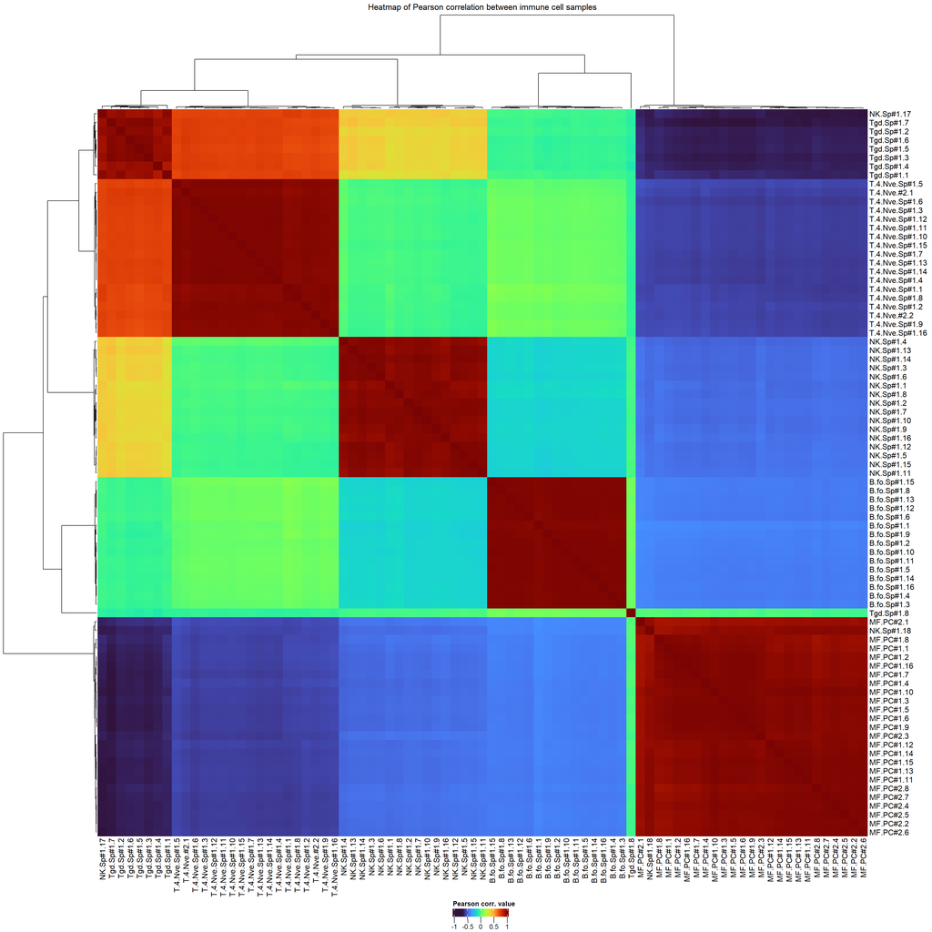

```r
# Create a Heatmap object
trimmed_cor_heatmap <-
  Heatmap(rnaSeq_trimmed_cor.mx,                         # Supply our matrix
          cluster_rows = TRUE, cluster_columns = TRUE,   # Cluster on both rows and columns

          # Colour it with viridis
          col = viridis(1000, option = "turbo"),

          # Use column_title as the title of our heatmap
          column_title = "Heatmap of Pearson correlation between immune cell samples",

          # Rotate the legend horizontally and give it a title
          heatmap_legend_param = list(title = "Pearson corr. value",
                                      legend_direction = "horizontal"),

          row_dend_width = unit(2, "in"),
          column_dend_height = unit(2, "in")

         )

# Plot the heatmap
ComplexHeatmap::draw(trimmed_cor_heatmap,
     # Plot the legend on the bottom
     heatmap_legend_side = "bottom"
    )
```

### 1.4.3 Plot a correlation heatmap from all data available

Wow! Aside from a few off-target samples, most of our data is grouped by cell type. We see `NK.SP#1.17` has grouped with most of the `Tgd.Sp` samples, `NK.Sp#1.18` has correlated highly with the MF.PC series of cells, and `Tgd.Sp#1.8` appears to be living kind of in its own world. We do, however, see that most cell types are positively correlated to each other based on the rusty red boxes along our diagonals! We even have some strong **negative correlations** between our MF.PC (macrophage) and Tgd.Sp (gamma-delta T) cells.

What if we were to look at all 4000 genes! Let’s repeat the experiment with the **full dataset**.

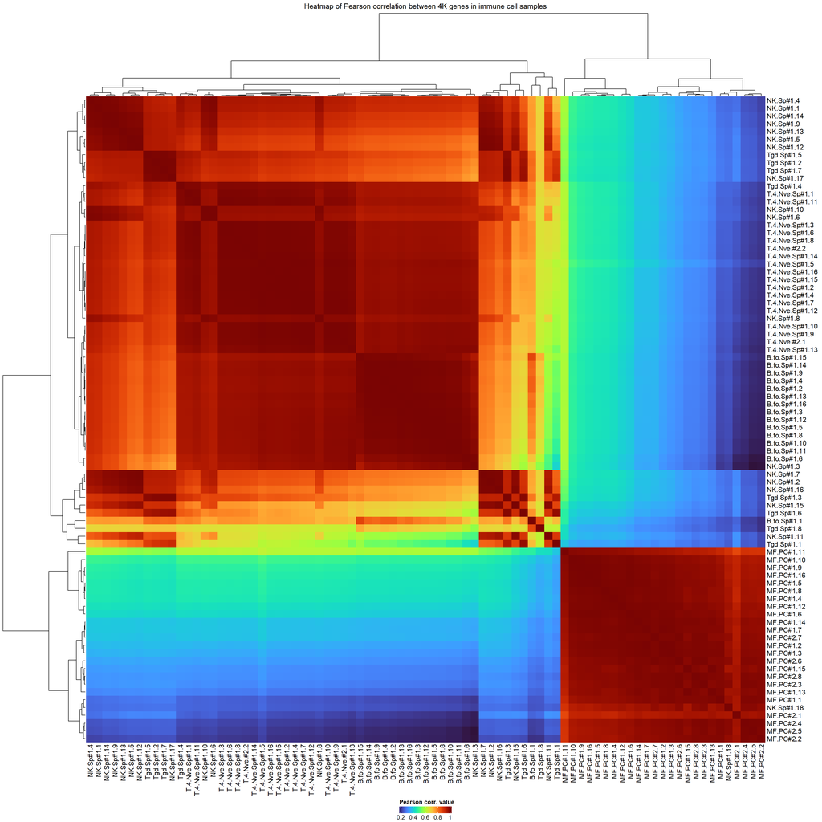

```r
# Make a matrix of our full 4K gene dataset
rnaSeq.mx <- as.matrix(rnaSeq.tbl[, -1])
rownames(rnaSeq.mx) <- pull(rnaSeq.tbl, 1)

rnaSeq_cor.mx <-
  cor(rnaSeq.mx, method = "pearson")

# Create a Heatmap object
pearsonCor_heatmap <-
  Heatmap(rnaSeq_cor.mx,               # Supply our matrix
          cluster_rows = TRUE, cluster_columns = TRUE,   # Cluster on both rows and columns

          # Colour it with viridis
          col = viridis(1000, option = "turbo"),

          # Use column_title as the title of our heatmap
          column_title = "Heatmap of Pearson correlation between 4K genes in immune cell samples",

          # Rotate the legend horizontally and give it a title
          heatmap_legend_param = list(title = "Pearson corr. value",
                                      legend_direction = "horizontal"),

          # Just increase the size of our dendrograms a little
          row_dend_width = unit(2, "in"),

          column_dend_height = unit(2, "in")

         )

# Plot the heatmap
ComplexHeatmap::draw(pearsonCor_heatmap,
     # Plot the legend on the bottom
     heatmap_legend_side = "bottom"
    )
```

### 1.4.4 Choose the correct correlation methods for your dataset

What happened to our heatmap?

From our output, it looks like when we added in more data points, we lost the power to really discriminate between all the immunocyte groups. This may have to do with our choice of Pearson correlation. In fact, we find that if we had used the Spearman correlation we would have replicated our results from the smaller set.

Let’s quickly make that small change to our code:

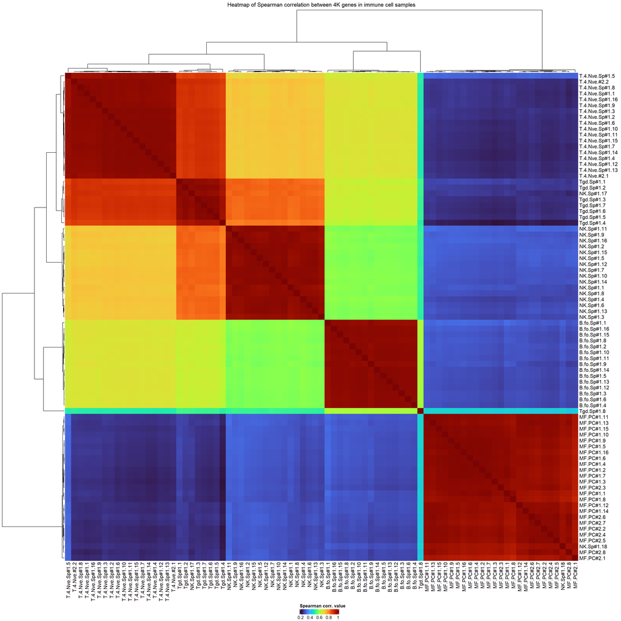

```r
# Make a matrix of our full 4K gene dataset
rnaSeq.mx <- as.matrix(rnaSeq.tbl[, -1])
rownames(rnaSeq.mx) <- pull(rnaSeq.tbl, 1)

# Create the correlation matrix
### Change the method to Spearman
rnaSeq_cor.mx <-
  cor(rnaSeq.mx, method = "spearman")

# Create a Heatmap object
spearmanCor_heatmap <-
  Heatmap(rnaSeq_cor.mx,                                 # Supply our matrix
          cluster_rows = TRUE, cluster_columns = TRUE,   # Cluster on both rows and columns

          # Colour it with viridis
          col = viridis(1000, option = "turbo"),

          # Use column_title as the title of our heatmap
          column_title = "Heatmap of Spearman correlation between 4K genes in immune cell samples",

          # Rotate the legend horizontally and give it a title
          heatmap_legend_param = list(title = "Spearman corr. value",
                                      legend_direction = "horizontal"),

          # Just increase the size of our dendrograms a little
          row_dend_width = unit(2, "in"),

          column_dend_height = unit(2, "in")

         )

# Plot the heatmap
ComplexHeatmap::draw(spearmanCor_heatmap,
     # Plot the legend on the bottom
     heatmap_legend_side = "bottom"
    )
```

### 1.4.5 Concatenate multiple heatmaps together into a `HeatmapList` object

Our heatmaps above are drawn from a single dataset which we’ve analysed in 2 ways - Pearson vs Spearman correlation. In the case where you might have more richly detailed metadata sets where you want to compare correlations for multiple sets of variables on the same samples, it will be helpful to make a `HeatmapList` to store and display your multiple heatmaps.

This object is literally a list-like object of heatmaps objects. We can make one from our two previous heatmaps `pearsonCor_heatmap` and `spearmanCor_heatmap`.

```r
# Make the heatmap list
hm_list <- spearmanCor_heatmap + pearsonCor_heatmap

# What kind of object is hm_list?
class(hm_list)
```

```
## [1] "HeatmapList"
## attr(,"package")
## [1] "ComplexHeatmap"
```

### 1.4.6 `draw()` your `HeatmapList`

Now that we have our `HeatmapList` we can simply draw the whole thing and it will automatically concatenate for us. Of course there are many options we can use to display the list. One thing to note is that the *clustering of columns in each heatmap is independent* while the *clustering of rows (and thus order) is based on only the first heatmap* (by default).

Using the `ComplexHeatmap::draw()` method to display your `HeatmapList` will allow you to further customize details of the overall figure including setting `row_title` and `column_title` for the entire figure.

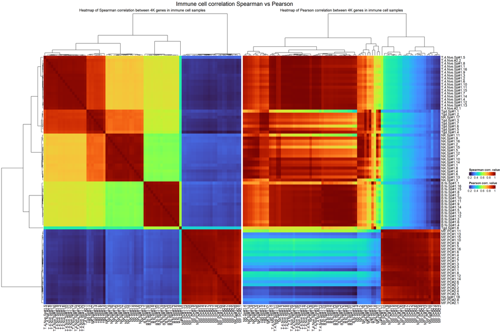

```r
ComplexHeatmap::draw(hm_list,
     column_title = "Immune cell correlation Spearman vs Pearson",
     column_title_gp = gpar(fontsize = 20)    # gpar() sets graphical parameters settings
    )
```

## 1.5.0 Make a cluster dendrogram with `hclust()`

As you can see, ordering our data (on the right metric!) makes a big difference in how our data is displayed. In our last few heatmaps, we allowed `Heatmap()` to generate its own clustering. We could have supplied it with a specific function to calculate distances, or even a dendrogram object to order the data as well. Under the hood, the function is defaulting to euclidean distances and actually passing that information on to the `hclust()` function to produce the dendrograms.

The choice of `method` determines how the data is clustered. The choices include: ward.D, ward.D2, single, complete (default), average, mcquitty, median and centroid.

In *general* **ward.D**, **ward.D2** and **complete** strategies try to find compact small “spherical” clusters. The **single** linkage method adopts a ‘friends of friends’ clustering strategy. The other methods can be said to aim for somewhere in between. For more information on these, you can dig into the [`hclust()` documentation](https://stat.ethz.ch/R-manual/R-patched/library/stats/html/hclust.html)

We can turn to `hclust()` to generate just dendrograms for us but prior to that we still need to reformat our matrix a little using the `dist()` function.

### 1.5.1 Calculate the distance between our points with `dist()`

Remember we talked about our data being in n-dimensional space? Using those coordinates, there are a number of ways to calculate the distance between points. The simplest form is to calculate the euclidean distance between points using the generic formula:

$$d(p,q) = \sqrt{(p_{1}-q_{2})^2 +
(p_{2}-q_{2})^2 + \ldots + (p_{n}-q_{n})^2}$$

but there are a number of other options as well. For instance you can also choose the maximum distance between two components (same dimension). The `dist()` function can generate these values for you using the parameter `method` to determine how the distance will be used. Your options are: euclidean, maximum, manhattan, canberra, binary or minkowski.

The `dist()` function will return a `dist` object which is a lower triangle distance matrix between all of the **rows/observations** using the columns as coordinates.

Let’s return to our trimmed RNAseq data in `rnaSeq_trimmed.mx` to try it out and see how it works. Let’s look at building the dendrogram of our samples so see how they might be related to each other. Recall that each row is currently a different gene in our dataset, while the columns are sample names. Therefore we’ll need to also *transpose* the matrix with the `t()` function.

```r
# Generate our distance matrix

dist(t(rnaSeq_trimmed.mx),       # Transpose the matrix
     method = "euclidean", ) %>% # The default method is euclidean
  # Show the structure of our output
  str()
```

```
##  'dist' num [1:3403] 1929 2240 2054 2080 2032 ...
##  - attr(*, "Size")= int 83
##  - attr(*, "Labels")= chr [1:83] "B.fo.Sp#1.1" "B.fo.Sp#1.10" "B.fo.Sp#1.11" "B.fo.Sp#1.12" ...
##  - attr(*, "Diag")= logi FALSE
##  - attr(*, "Upper")= logi FALSE
##  - attr(*, "method")= chr "euclidean"
##  - attr(*, "call")= language dist(x = t(rnaSeq_trimmed.mx), method = "euclidean")
```

### 1.5.2 Cluster your distance matrix

Now that we can see how a distance matrix is made, we can cluster it using the `hclust()` method

Parameters that are important:

- `method`: already described as the method which we want to use to cluster our data.
  - ward.D, ward.D2, single, complete (default), average, mcquitty, median and centroid.
- `k`: the number of groups we would like our final data to be split into - represented by colours.

```r
# Make a cluster object and take a look at it
rnaSeq.hc <- hclust(dist(t(rnaSeq_trimmed.mx)),
                 method = "ward.D2")

# What does our hclust object contain?
str(rnaSeq.hc)
```

```
## List of 7
##  $ merge      : int [1:82, 1:2] -27 -63 -60 -23 -62 -5 -72 -78 -20 -64 ...
##  $ height     : num [1:82] 855 862 899 921 940 ...
##  $ order      : int [1:83] 30 16 29 23 24 34 26 25 31 27 ...
##  $ labels     : chr [1:83] "B.fo.Sp#1.1" "B.fo.Sp#1.10" "B.fo.Sp#1.11" "B.fo.Sp#1.12" ...
##  $ method     : chr "ward.D2"
##  $ call       : language hclust(d = dist(t(rnaSeq_trimmed.mx)), method = "ward.D2")
##  $ dist.method: chr "euclidean"
##  - attr(*, "class")= chr "hclust"
```

```r
# What does our merge matrix look like?
head(rnaSeq.hc$merge)
```

```
##      [,1] [,2]
## [1,]  -27  -28
## [2,]  -63  -70
## [3,]  -60  -74
## [4,]  -23  -24
## [5,]  -62  -65
## [6,]   -5   -6
```

### 1.5.3 Plot your cluster object using `fviz_dend()` from the package `factoextra`

Now that we have generated our clustering object, you can see that it holds a number of features including the height (length) of our branches, an ordering of our samples and the order in which they `merge`. The `merge` process is described in more detail as well with the `hclust()` [documentation](https://stat.ethz.ch/R-manual/R-patched/library/stats/html/hclust.html). For instance, our merge matrix indicates that label 60 (T.4.Nve.Sp#1.1) is joined to label 74 (T.4.Nve.Sp#1.8).

We can treat the resulting plot like a ggplot to update particular elements as well.

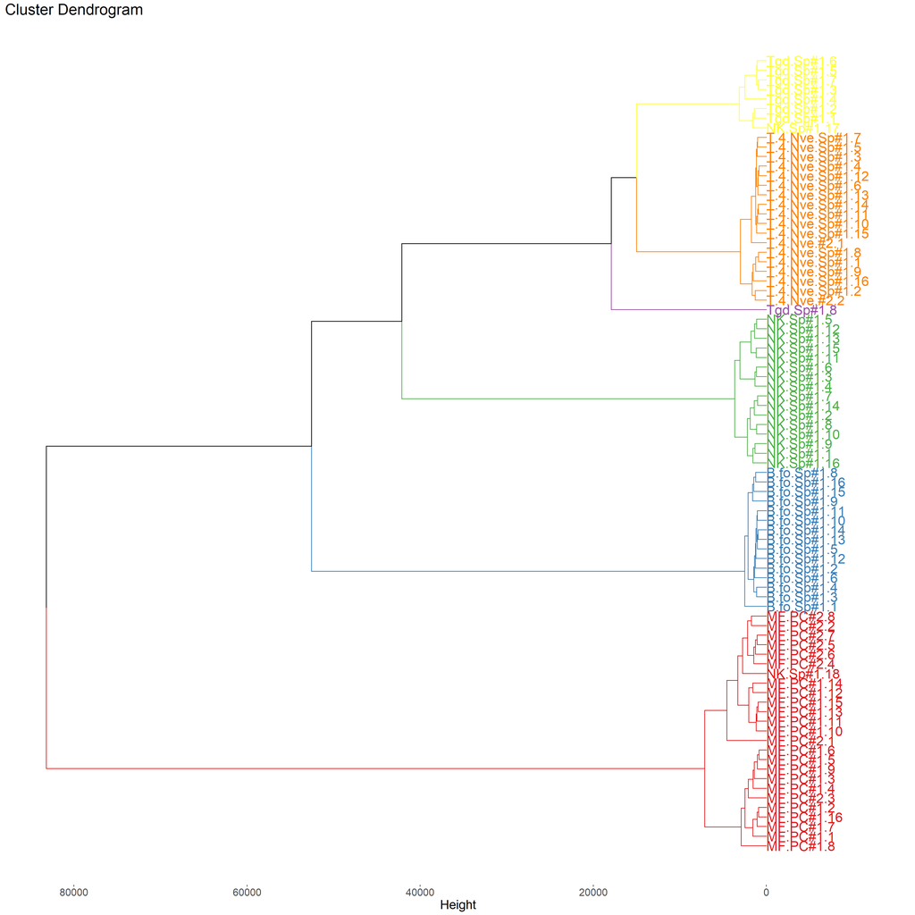

```r
# Plot out our dendrogram with fviz_dend

fviz_dend(rnaSeq.hc,                        # provide our hclust object
          cex = 1.5,                     # set the text size to be larger
          k = 6,                         # How many clusters do we expect in our data
          palette = "Set1",              # what colours will we use. Many options including RBrewer palettes
          horiz = TRUE,
          labels_track_height = 12000,
         ) +

    # Bump up the text size for my old eyes
    theme(text = element_text(size = 20))
```

What if we were to repeat this process with the entire dataset of 4K genes? Perhaps more data would clarify where that single sample belongs?

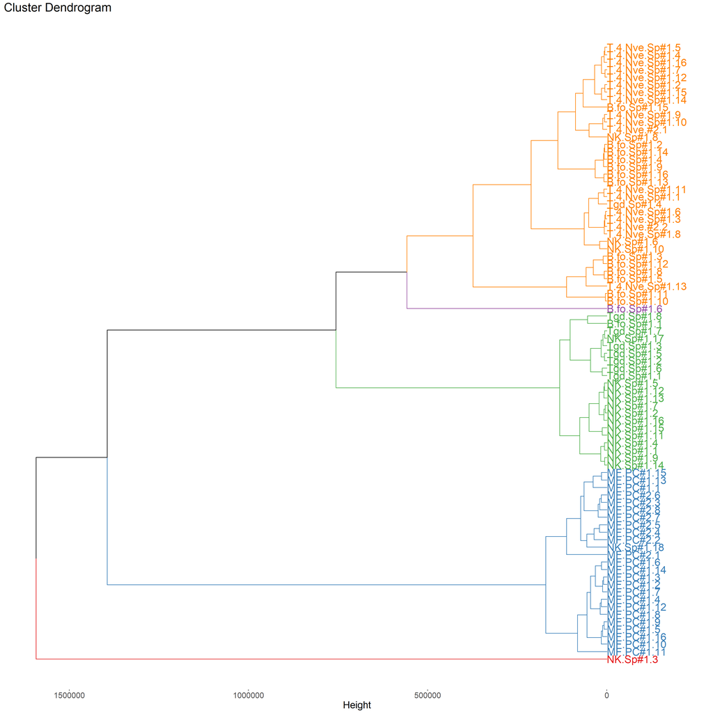

```r
# Retry the same procedure with our full dataset
hclust(dist(t(rnaSeq.mx)),
                 method = "ward.D2") %>%

# Plot out our dendrogram with fviz_dend
fviz_dend(.,                        # provide our hclust object
          cex = 1.5,                     # set the text size to be larger
          k = 5,                         # How many clusters do we expect in our data
          palette = "Set1",              # what colours will we use. Many options including RBrewer palettes
          horiz = TRUE,
          # labels_track_height = 12000, axes = FALSE
         ) +

    # Bump up the text size for my old eyes
    theme(text = element_text(size = 20))
```

### 1.5.4 More data does not necessarily grant more clarity!

Looks like adding in *more* information didn’t really clean up the relationship. It could be that picking a different clustering method might also affect the outcome but let’s revisit some conclusions:

1. Using smaller range of *mean* read count values, and limiting our analysis to the top 100-200 genes in that range, reproduced (for the most part) the presumed cell types between our various immune cell samples. This was accomplished through Pearson correlation and euclidean distance mapping of nearest neighbours.
2. Using the full dataset resulted in worse correlation and differentiation of cell types, depended on the methods used. Overall, however, more data did not necessarily result in more accurate analyses.

One of our problems with successfully using these methods on our “full” dataset may come from an *excess* of “junk” information!

Recall that our data already represents a trimmed down set of data from 55K genes to ~4K genes. If we were to take a look at these samples and cluster them along the 4K gene symbols, it would be quite computationally expensive. Some genes may not even have any interesting information if they have the same or very similar counts along all or most of the 83 samples. When generating RNAseq data, you are taking a snapshot of a sample which will have a specific expression profile based on cell type, cell cycle, and other conditions. Thus not all genes will even by expressed!

If the majority of genes, let’s say more than 90% for instance, are very similar in signal strength, then the other 10% (or fewer) of genes that do show diversity between conditions can be easily drowned out - especially in a mathematical calculation like Pearson correlation!

How do we deal with this reality? How do we distinguish the useful signals from the steady-state signals?

# 2.0.0 Clustering data into groups

So we’ve visualized our dataset as a dendrogram and it gives us an idea of how the samples might be related (in n-dimension space) based on the **read counts** we produced from normalization. There was a crucial step to our last visualization, however, where we had to guess how many clusters (groups) our data would divide into. This was used to help colour parts of our tree into green, blue, red, etc. This, however, was a bit of a guess. On a deeper level, what goes unanswered by a simple glance of the figure is **how** the function decided where each group would begin and end? If we had picked k = 6, or 7, it would become more evident that the groups were broken by the most ancestral internal nodes/bifurcations in our dendrogram.

Under the hood of our process, K-means clustering implements an unsupervised learning for uncategorized data. We don’t really know the training labels of our data and are more interested in seeing which ones group together. How many clusters should we aim to generate? We’ve already seen that our data likely splits into 5 main groups based on the heatmaps and `hclust()` data. Will we get the same thing with a k-means method?

When in doubt, you can quickly consult the `factoMiner::fviz_nbclust()` function which can guess how many clusters are ideal for representing your *rows/observations* of data. Note that it may not produce your ideal number of clusters but if you’re stuck, this is a good start.

There are three `method` options: wss, gap_stat, and silhouette which all aim to minimize the number of clusters.

- `wss` elbow method aims to minimize intracluster variation. How compact is our clustering? A lower WSS is better.
- `silhouette` measures how well an object lies within its cluster by computing the average distance to other members in its own, $a(i)$ vs other clusters $b(i)$. We evaluate $\frac{b(i) - a(i)}{max\{a(i), b(i)}$ with higher values indicating better clustering. In this case, the location of the maximum value is considered the optimal cluster.
- `gap_stat` also compares total intra-cluster variation but against a null reference distribution. There are a few potential ways to interpret this for optimal value. The first, is simply to maximize for the best gap stat value but this can be problematic if our output shows increasing gap statistic values with increasing k. On a similar vein, you can look for the biggest jumps/gains in gap statistic which suggests a much more informative clustering than the previous k value. Lastly, a 1-standard-error method has been proposed which attempts to choose the number of clusters such that the smallest `k` gap statistic is within one standard deviation of the gap at `k+1`.

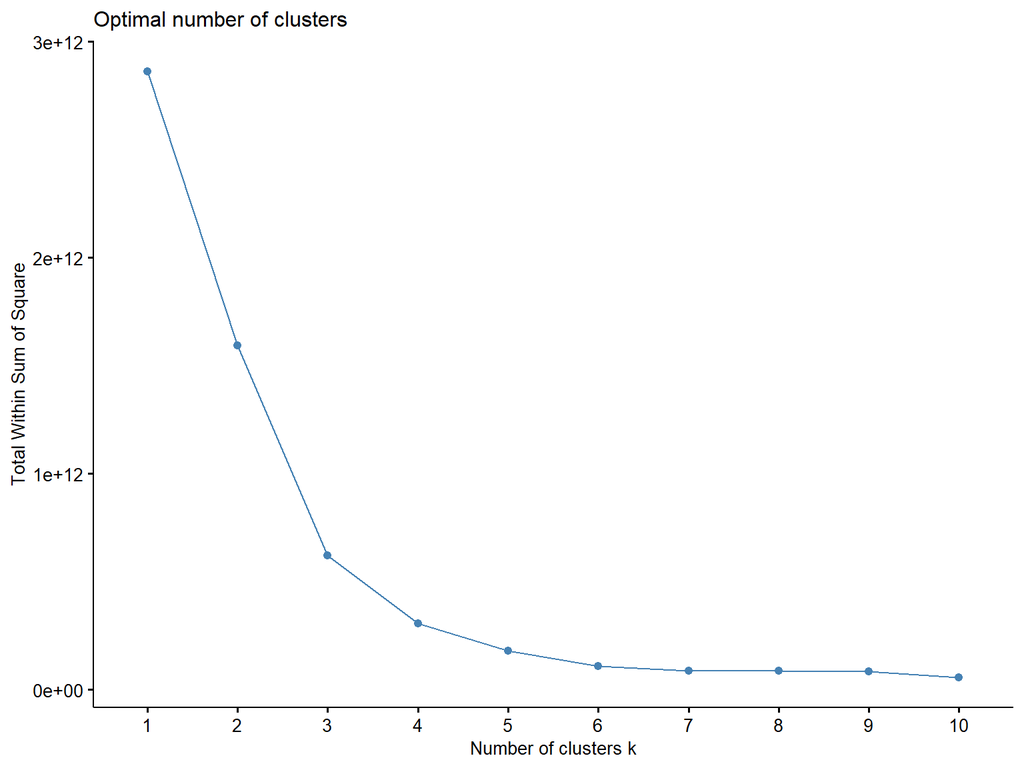

```r
# How many clusters should we generate based on our rows?

fviz_nbclust(x = t(rnaSeq.mx),                      # Provide the transposed dataset
             FUNcluster =  kmeans,                  # How will you cluster the data?
             method="wss") +                        # What method will you use?

  theme(text = element_text(size=10))
```

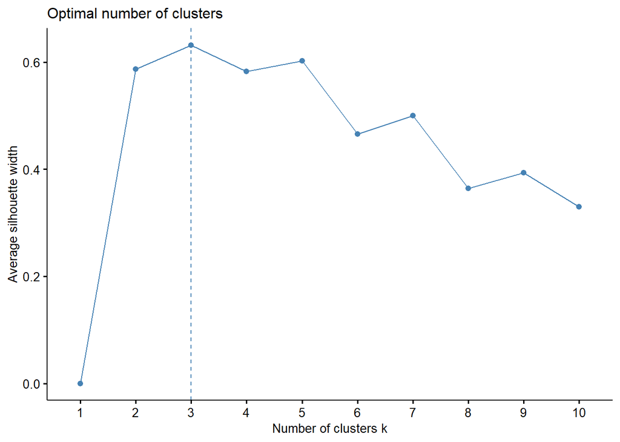

```r
# How many clusters should we generate by silhouette?
fviz_nbclust(x = t(rnaSeq.mx),                      # Provide the dataset
             FUNcluster =  kmeans,                  # How will you cluster the data?
             method="silhouette") +                 # What method will you use?

  theme(text = element_text(size=10))
```

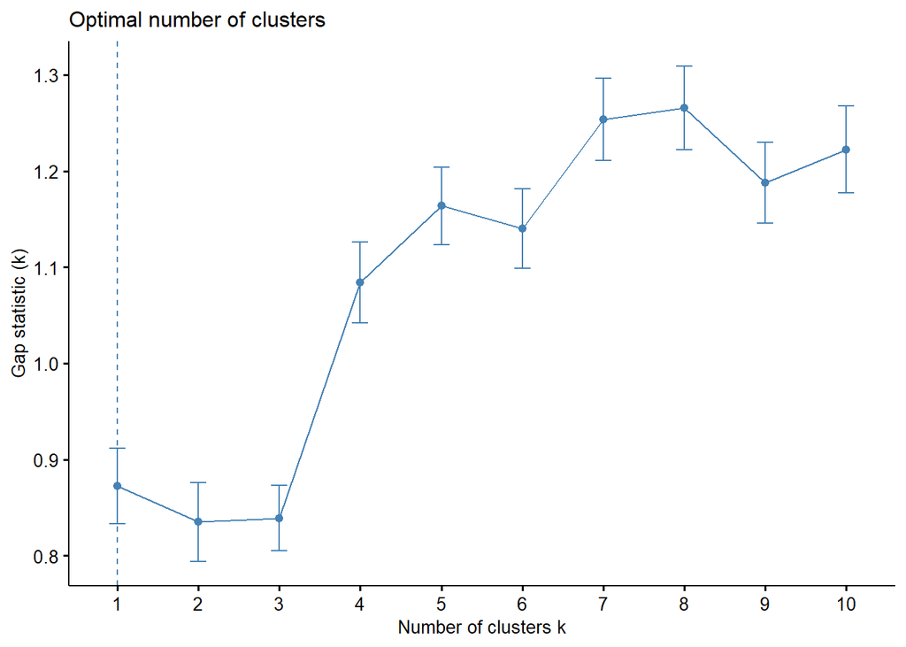

```r
# How many clusters should we generate by gapstat??
fviz_nbclust(x = t(rnaSeq.mx),                      # Provide the dataset
             FUNcluster =  kmeans,                  # How will you cluster the data?
             method="gap_stat") +                   # What method will you use?

  theme(text = element_text(size=10))
```